# EDA Analisis Exploratoro de Datos Estadistica Multidimensional

Juan Pablo Mosquera Marin - 20221020026 Ana Laura Morcote Chacon - 20221020010 Hana Sofia Pinilla Manrique - 20221020092 Juan David Amaya Patiño - 20221020057

2026-08-26

# 1 Instalación de paquetes

> Verificacion si los paquetas estan intalados, los que no esten se proceden a instalar.

# 2 Carga de librerías y datos

## 2.1 Librerías iniciales

```r
library(readr)
library(here)
```

## 2.2 Wealth -> Lectura del primer dataset opcionado

Se ve que el dataset de `wealth_accumulation_master.csv`, tiene un total de 55.000 registros y 25 varables. Las cuales estan divididas por el momento en cuatro variables categoricas de tipo character y 21 variables de tipo numeric, con as su vez un total de cero nulos en todas las variables.

```r
datos <- read_csv(here("DATASET", "wealth_accumulation_master.csv"))
spec(datos)
dim(datos)
```

```
## [1] 55000    25
```

```r
str(datos)
```

```
## spc_tbl_ [55,000 × 25] (S3: spec_tbl_df/tbl_df/tbl/data.frame)
##  $ person_id                 : chr [1:55000] "PSN000000" "PSN000001" "PSN000002" "PSN000003" ...
##  $ age                       : num [1:55000] 45 38 56 57 35 33 31 55 43 38 ...
##  $ years_working             : num [1:55000] 20 17 34 34 12 16 8 33 25 17 ...
##  $ education                 : chr [1:55000] "some_college" "bachelors" "some_college" "high_school" ...
##  $ annual_income             : num [1:55000] 79700 105800 128700 54100 33700 ...
##  $ parental_wealth_bracket   : chr [1:55000] "lower_mid" "upper_mid" "lower_mid" "middle" ...
##  $ inheritance_received      : num [1:55000] 0 141300 5200 0 0 ...
##  $ homeowner                 : num [1:55000] 1 1 0 0 1 0 0 1 0 0 ...
##  $ region_cost_of_living     : chr [1:55000] "low" "medium" "high" "high" ...
##  $ dependents                : num [1:55000] 0 0 1 1 4 4 2 0 2 1 ...
##  $ health_shock              : num [1:55000] 0 0 0 0 0 0 1 1 0 0 ...
##  $ savings_rate              : num [1:55000] 0.13 0.254 0.267 0.272 0.106 0.365 0.118 0.426 0.14 0.044 ...
##  $ invests_in_markets        : num [1:55000] 0 1 0 0 1 0 0 1 1 1 ...
##  $ portfolio_equity_pct      : num [1:55000] 5 50 2 0 25 11 0 94 100 61 ...
##  $ diversification_score     : num [1:55000] 5.3 8.3 4.5 0.1 2.1 5.6 2.7 5.9 2.9 4.2 ...
##  $ financial_literacy        : num [1:55000] 6.3 7.1 5.8 6.9 10 4 5.2 6.2 8.7 6.1 ...
##  $ budgeting_consistency     : num [1:55000] 5.9 6 5.4 4.7 6.1 5 9.9 4.3 2.3 1.5 ...
##  $ impulse_spending          : num [1:55000] 3.1 1.9 2.5 1.2 4 3.9 2.2 0 2 5.4 ...
##  $ plans_ahead               : num [1:55000] 9.4 8.6 8.7 10 10 6 7.9 5.4 10 5 ...
##  $ carries_high_interest_debt: num [1:55000] 0 0 0 0 1 0 1 0 1 0 ...
##  $ retirement_account        : num [1:55000] 0 1 1 0 1 0 1 1 1 0 ...
##  $ started_investing_age     : num [1:55000] 22 44 19 21 22 32 21 18 18 21 ...
##  $ years_investing           : num [1:55000] 23 0 37 36 13 1 10 37 25 17 ...
##  $ net_worth                 : num [1:55000] 562600 765400 1081100 119600 218800 ...
##  $ financially_independent   : num [1:55000] 0 0 0 0 0 0 0 1 0 0 ...
##  - attr(*, "spec")=
##   .. cols(
##   ..   person_id = col_character(),
##   ..   age = col_double(),
##   ..   years_working = col_double(),
##   ..   education = col_character(),
##   ..   annual_income = col_double(),
##   ..   parental_wealth_bracket = col_character(),
##   ..   inheritance_received = col_double(),
##   ..   homeowner = col_double(),
##   ..   region_cost_of_living = col_character(),
##   ..   dependents = col_double(),
##   ..   health_shock = col_double(),
##   ..   savings_rate = col_double(),
##   ..   invests_in_markets = col_double(),
##   ..   portfolio_equity_pct = col_double(),
##   ..   diversification_score = col_double(),
##   ..   financial_literacy = col_double(),
##   ..   budgeting_consistency = col_double(),
##   ..   impulse_spending = col_double(),
##   ..   plans_ahead = col_double(),
##   ..   carries_high_interest_debt = col_double(),
##   ..   retirement_account = col_double(),
##   ..   started_investing_age = col_double(),
##   ..   years_investing = col_double(),
##   ..   net_worth = col_double(),
##   ..   financially_independent = col_double()
##   .. )
##  - attr(*, "problems")=<pointer: 0x0000021574ffed10>
```

```r
colSums(is.na(datos))
```

```
##                  person_id                        age
##                          0                          0
##              years_working                  education
##                          0                          0
##              annual_income    parental_wealth_bracket
##                          0                          0
##       inheritance_received                  homeowner
##                          0                          0
##      region_cost_of_living                 dependents
##                          0                          0
##               health_shock               savings_rate
##                          0                          0
##         invests_in_markets       portfolio_equity_pct
##                          0                          0
##      diversification_score         financial_literacy
##                          0                          0
##      budgeting_consistency           impulse_spending
##                          0                          0
##                plans_ahead carries_high_interest_debt
##                          0                          0
##         retirement_account      started_investing_age
##                          0                          0
##            years_investing                  net_worth
##                          0                          0
##    financially_independent
##                          0
```

## 2.3 Wealth -> Resumen estadístico

De `wealth_accumulation_master.csv`

```r
summary(datos)
```

```
##      person_id          age        years_working       education
##  Length   :55000   Min.   :22.00   Min.   : 0.00   Length   :55000
##  N.unique :55000   1st Qu.:36.00   1st Qu.:13.00   N.unique :    4
##  N.blank  :    0   Median :45.00   Median :22.00   N.blank  :    0
##  Min.nchar:    9   Mean   :45.16   Mean   :22.26   Min.nchar:    8
##  Max.nchar:    9   3rd Qu.:54.00   3rd Qu.:31.00   Max.nchar:   12
##                    Max.   :80.00   Max.   :55.00
##  annual_income    parental_wealth_bracket inheritance_received   homeowner
##  Min.   : 12000   Length   :55000         Min.   :      0      Min.   :0.0000
##  1st Qu.: 55300   N.unique :    5         1st Qu.:      0      1st Qu.:0.0000
##  Median : 80900   N.blank  :    0         Median :      0      Median :1.0000
##  Mean   : 94777   Min.nchar:    3         Mean   : 110176      Mean   :0.6095
##  3rd Qu.:118000   Max.nchar:    9         3rd Qu.:  34000      3rd Qu.:1.0000
##  Max.   :884900                           Max.   :6000000      Max.   :1.0000
##  region_cost_of_living   dependents     health_shock     savings_rate
##  Length   :55000       Min.   :0.000   Min.   :0.0000   Min.   :0.0000
##  N.unique :    3       1st Qu.:0.000   1st Qu.:0.0000   1st Qu.:0.1370
##  N.blank  :    0       Median :1.000   Median :0.0000   Median :0.2200
##  Min.nchar:    3       Mean   :1.107   Mean   :0.1397   Mean   :0.2383
##  Max.nchar:    6       3rd Qu.:2.000   3rd Qu.:0.0000   3rd Qu.:0.3220
##                        Max.   :6.000   Max.   :1.0000   Max.   :0.6000
##  invests_in_markets portfolio_equity_pct diversification_score
##  Min.   :0.0000     Min.   :  0.00       Min.   : 0.000
##  1st Qu.:0.0000     1st Qu.:  9.00       1st Qu.: 4.100
##  Median :1.0000     Median : 29.00       Median : 5.700
##  Mean   :0.5674     Mean   : 34.85       Mean   : 5.666
##  3rd Qu.:1.0000     3rd Qu.: 58.00       3rd Qu.: 7.200
##  Max.   :1.0000     Max.   :100.00       Max.   :10.000
##  financial_literacy budgeting_consistency impulse_spending  plans_ahead
##  Min.   : 0.000     Min.   : 0.000        Min.   : 0.000   Min.   : 0.00
##  1st Qu.: 4.400     1st Qu.: 3.400        1st Qu.: 1.600   1st Qu.: 5.70
##  Median : 5.900     Median : 5.000        Median : 3.300   Median : 7.30
##  Mean   : 5.834     Mean   : 4.992        Mean   : 3.377   Mean   : 7.18
##  3rd Qu.: 7.300     3rd Qu.: 6.500        3rd Qu.: 5.000   3rd Qu.: 8.90
##  Max.   :10.000     Max.   :10.000        Max.   :10.000   Max.   :10.00
##  carries_high_interest_debt retirement_account started_investing_age
##  Min.   :0.0000             Min.   :0.0000     Min.   :18.00
##  1st Qu.:0.0000             1st Qu.:0.0000     1st Qu.:21.00
##  Median :0.0000             Median :1.0000     Median :27.00
##  Mean   :0.3117             Mean   :0.7166     Mean   :27.63
##  3rd Qu.:1.0000             3rd Qu.:1.0000     3rd Qu.:33.00
##  Max.   :1.0000             Max.   :1.0000     Max.   :59.00
##  years_investing   net_worth        financially_independent
##  Min.   : 0.0    Min.   : -150000   Min.   :0.0000
##  1st Qu.: 7.0    1st Qu.:  131700   1st Qu.:0.0000
##  Median :18.0    Median :  354350   Median :0.0000
##  Mean   :18.3    Mean   : 1209038   Mean   :0.1628
##  3rd Qu.:28.0    3rd Qu.:  999500   3rd Qu.:0.0000
##  Max.   :55.0    Max.   :60000000   Max.   :1.0000
```

## 2.4 Wealth -> Exploración de variables categóricas

De `wealth_accumulation_master.csv`

```r
unique(datos$education)
```

```
## [1] "some_college" "bachelors"    "high_school"  "graduate"
```

```r
unique(datos$parental_wealth_bracket)
```

```
## [1] "lower_mid" "upper_mid" "middle"    "top"       "bottom"
```

```r
unique(datos$region_cost_of_living)
```

```
## [1] "low"    "medium" "high"
```

# 3 Wealth -> Traducción y recodificación de variables

Se renombran las columnas al español y se recodifican las categorías de las variables `educacion`, `nivel_riqueza_parental` y `costo_vida_region`.

```r
library(dplyr)

datos_spa <- datos %>%
  rename(
    id_persona                    = person_id,
    edad                          = age,
    anios_trabajando              = years_working,
    educacion                     = education,
    ingreso_anual                 = annual_income,
    nivel_riqueza_parental        = parental_wealth_bracket,
    herencia_recibida             = inheritance_received,
    propietario_vivienda          = homeowner,
    costo_vida_region             = region_cost_of_living,
    dependientes                  = dependents,
    shock_salud                   = health_shock,
    tasa_ahorro                   = savings_rate,
    invierte_en_mercados          = invests_in_markets,
    pct_portafolio_acciones       = portfolio_equity_pct,
    puntaje_diversificacion       = diversification_score,
    alfabetizacion_financiera     = financial_literacy,
    consistencia_presupuesto      = budgeting_consistency,
    gasto_impulsivo               = impulse_spending,
    planificacion_futuro          = plans_ahead,
    tiene_deuda_alto_interes      = carries_high_interest_debt,
    cuenta_retiro                 = retirement_account,
    edad_inicio_inversion         = started_investing_age,
    anios_invirtiendo             = years_investing,
    patrimonio_neto               = net_worth,
    independiente_financieramente = financially_independent
  ) %>%
  mutate(
    educacion = recode(educacion,
                       "high_school"  = "secundaria",
                       "some_college" = "universidad_incompleta",
                       "bachelors"    = "licenciatura",
                       "graduate"     = "posgrado"
    ),
    nivel_riqueza_parental = recode(nivel_riqueza_parental,
                                    "bottom"    = "bajo",
                                    "lower_mid" = "medio_bajo",
                                    "middle"    = "medio",
                                    "upper_mid" = "medio_alto",
                                    "top"       = "alto"
    ),
    costo_vida_region = recode(costo_vida_region,
                               "low"    = "bajo",
                               "medium" = "medio",
                               "high"   = "alto"
    )
  )
```

## 3.1 Wealth -> Verificación de la traducción

Se verifica que la traduccion se haya hecho correctamente

```r
str(datos_spa)
```

```
## tibble [55,000 × 25] (S3: tbl_df/tbl/data.frame)
##  $ id_persona                   : chr [1:55000] "PSN000000" "PSN000001" "PSN000002" "PSN000003" ...
##  $ edad                         : num [1:55000] 45 38 56 57 35 33 31 55 43 38 ...
##  $ anios_trabajando             : num [1:55000] 20 17 34 34 12 16 8 33 25 17 ...
##  $ educacion                    : chr [1:55000] "universidad_incompleta" "licenciatura" "universidad_incompleta" "secundaria" ...
##  $ ingreso_anual                : num [1:55000] 79700 105800 128700 54100 33700 ...
##  $ nivel_riqueza_parental       : chr [1:55000] "medio_bajo" "medio_alto" "medio_bajo" "medio" ...
##  $ herencia_recibida            : num [1:55000] 0 141300 5200 0 0 ...
##  $ propietario_vivienda         : num [1:55000] 1 1 0 0 1 0 0 1 0 0 ...
##  $ costo_vida_region            : chr [1:55000] "bajo" "medio" "alto" "alto" ...
##  $ dependientes                 : num [1:55000] 0 0 1 1 4 4 2 0 2 1 ...
##  $ shock_salud                  : num [1:55000] 0 0 0 0 0 0 1 1 0 0 ...
##  $ tasa_ahorro                  : num [1:55000] 0.13 0.254 0.267 0.272 0.106 0.365 0.118 0.426 0.14 0.044 ...
##  $ invierte_en_mercados         : num [1:55000] 0 1 0 0 1 0 0 1 1 1 ...
##  $ pct_portafolio_acciones      : num [1:55000] 5 50 2 0 25 11 0 94 100 61 ...
##  $ puntaje_diversificacion      : num [1:55000] 5.3 8.3 4.5 0.1 2.1 5.6 2.7 5.9 2.9 4.2 ...
##  $ alfabetizacion_financiera    : num [1:55000] 6.3 7.1 5.8 6.9 10 4 5.2 6.2 8.7 6.1 ...
##  $ consistencia_presupuesto     : num [1:55000] 5.9 6 5.4 4.7 6.1 5 9.9 4.3 2.3 1.5 ...
##  $ gasto_impulsivo              : num [1:55000] 3.1 1.9 2.5 1.2 4 3.9 2.2 0 2 5.4 ...
##  $ planificacion_futuro         : num [1:55000] 9.4 8.6 8.7 10 10 6 7.9 5.4 10 5 ...
##  $ tiene_deuda_alto_interes     : num [1:55000] 0 0 0 0 1 0 1 0 1 0 ...
##  $ cuenta_retiro                : num [1:55000] 0 1 1 0 1 0 1 1 1 0 ...
##  $ edad_inicio_inversion        : num [1:55000] 22 44 19 21 22 32 21 18 18 21 ...
##  $ anios_invirtiendo            : num [1:55000] 23 0 37 36 13 1 10 37 25 17 ...
##  $ patrimonio_neto              : num [1:55000] 562600 765400 1081100 119600 218800 ...
##  $ independiente_financieramente: num [1:55000] 0 0 0 0 0 0 0 1 0 0 ...
```

```r
colSums(is.na(datos_spa))
```

```
##                    id_persona                          edad
##                             0                             0
##              anios_trabajando                     educacion
##                             0                             0
##                 ingreso_anual        nivel_riqueza_parental
##                             0                             0
##             herencia_recibida          propietario_vivienda
##                             0                             0
##             costo_vida_region                  dependientes
##                             0                             0
##                   shock_salud                   tasa_ahorro
##                             0                             0
##          invierte_en_mercados       pct_portafolio_acciones
##                             0                             0
##       puntaje_diversificacion     alfabetizacion_financiera
##                             0                             0
##      consistencia_presupuesto               gasto_impulsivo
##                             0                             0
##          planificacion_futuro      tiene_deuda_alto_interes
##                             0                             0
##                 cuenta_retiro         edad_inicio_inversion
##                             0                             0
##             anios_invirtiendo               patrimonio_neto
##                             0                             0
## independiente_financieramente
##                             0
```

```r
unique(datos_spa$educacion)
```

```
## [1] "universidad_incompleta" "licenciatura"           "secundaria"
## [4] "posgrado"
```

```r
unique(datos_spa$nivel_riqueza_parental)
```

```
## [1] "medio_bajo" "medio_alto" "medio"      "alto"       "bajo"
```

```r
unique(datos_spa$costo_vida_region)
```

```
## [1] "bajo"  "medio" "alto"
```

# 4 Wealth -> Análisis de correlación — Dataset de riqueza

Conversion de variables categoricas a numericas para la matriz de correlacion y eliminacion de la variable `id_persona`. debido a que no aporta al ser el identificador unico de cada registro

```r
library(dplyr)

# Codificar las variables categóricas ordinales como numéricas
datos_numericos <- datos_spa %>%
  mutate(
    educacion = recode(educacion,
                       "secundaria"             = 1,
                       "universidad_incompleta" = 2,
                       "licenciatura"           = 3,
                       "posgrado"               = 4
    ),
    nivel_riqueza_parental = recode(nivel_riqueza_parental,
                                    "bajo"       = 1,
                                    "medio_bajo" = 2,
                                    "medio"      = 3,
                                    "medio_alto" = 4,
                                    "alto"       = 5
    ),
    costo_vida_region = recode(costo_vida_region,
                               "bajo"  = 1,
                               "medio" = 2,
                               "alto"  = 3
    )
  ) %>%
  select(-id_persona) %>%
  select(where(is.numeric))

# Verificar qué variables quedaron
names(datos_numericos)
```

```
##  [1] "edad"                          "anios_trabajando"
##  [3] "educacion"                     "ingreso_anual"
##  [5] "nivel_riqueza_parental"        "herencia_recibida"
##  [7] "propietario_vivienda"          "costo_vida_region"
##  [9] "dependientes"                  "shock_salud"
## [11] "tasa_ahorro"                   "invierte_en_mercados"
## [13] "pct_portafolio_acciones"       "puntaje_diversificacion"
## [15] "alfabetizacion_financiera"     "consistencia_presupuesto"
## [17] "gasto_impulsivo"               "planificacion_futuro"
## [19] "tiene_deuda_alto_interes"      "cuenta_retiro"
## [21] "edad_inicio_inversion"         "anios_invirtiendo"
## [23] "patrimonio_neto"               "independiente_financieramente"
```

```r
dim(datos_numericos)
```

```
## [1] 55000    24
```

## 4.1 Wealth -> Matriz de correlación (completa)

## 4.2 Wealth -> Visualización — Matriz de correlación completa

Al tener l;a visualizacion de de la Matriz de correlación, se puede ver claramente que la gran mayoria de las varables del dataset `wealth_accumulation_master.csv` practicamente no tienen nula relacion entre si, a excepcion de algunas variables como: `edad` con `anios_trabajando` y `anios_invertiendo`, a su vez `invierte_en_mercados` con `pct_portafolio_acciones`.

Por lo cual se excluiran las variables `anios_trabajando`, `anios_invirtiendo` y `pct_portafolio_acciones` para reducir redundancia entre variables altamente correlacionadas y ver si con este cambio habra un cambio en la correlacion de la variables por si eran estas tres las que se llevaban todo el peso de las demas.

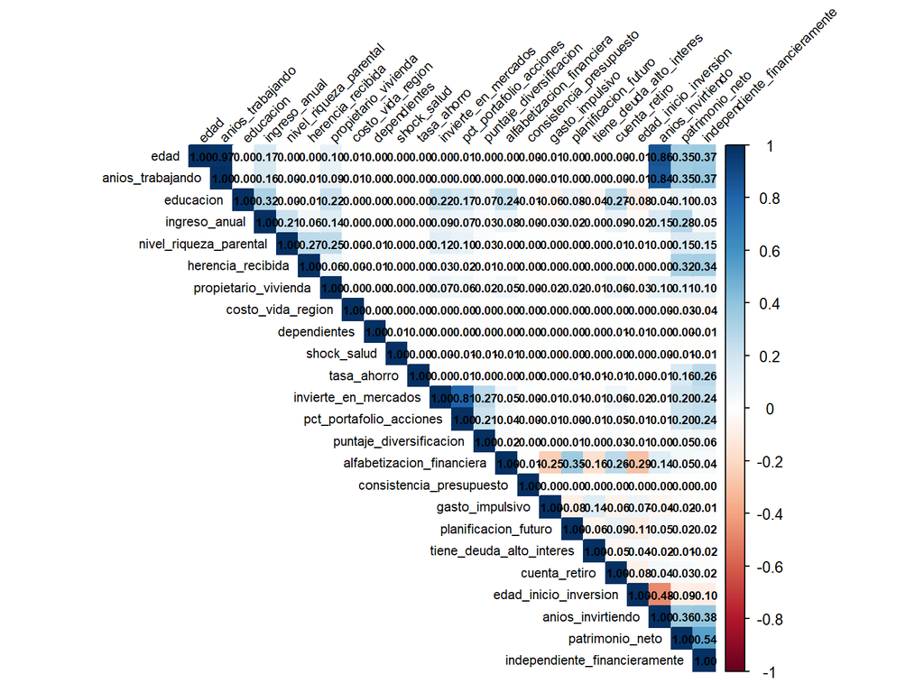

Matriz de correlación de todas las variables numéricas

```r
library(corrplot)

corrplot(matriz_cor,
         method = "color",
         type = "upper",
         tl.col = "black",
         tl.srt = 45,
         addCoef.col = "black",
         number.cex = 0.6,
         tl.cex = 0.7)
```

## 4.3 Wealth -> Matriz de correlación (variables filtradas)

## 4.4 Wealth -> Visualización — Matriz de correlación filtrada

Y como se puede ver en la siguiente matriz, la exclusion de las variables `anios_trabajando`, `anios_invirtiendo` y `pct_portafolio_acciones` lo unico que logro es que haya menos correlacion general entra las variables restantes, por lo cual se toma la decision de buscar un nuevo conjunto de datos el cual tenga una mejor correlacion entre sus variables para que asi se pueda usar y cumpla los requerimientos del curso de Estadistica Multidimensional.

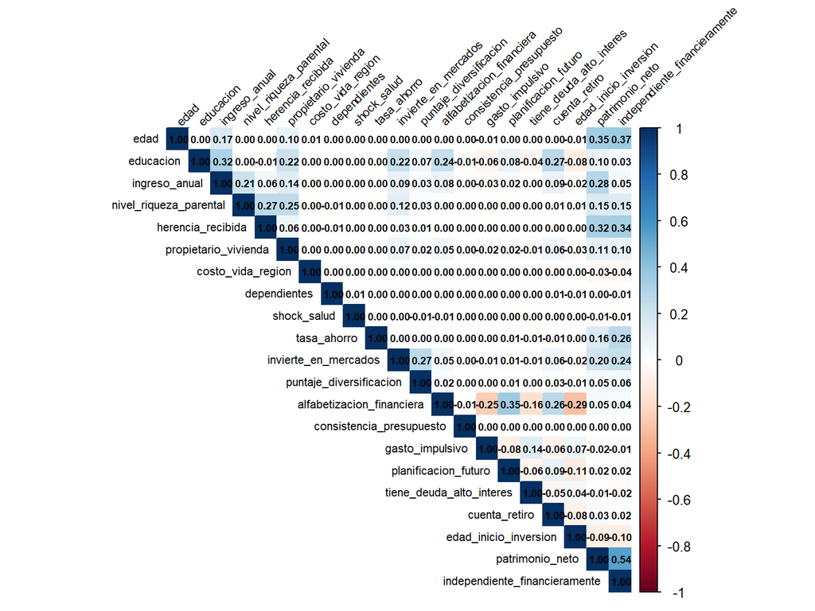

Matriz de correlación tras excluir variables redundantes

```r
corrplot(matriz_cor2,
         method = "color",
         type = "upper",
         tl.col = "black",
         tl.srt = 45,
         addCoef.col = "black",
         number.cex = 0.6,
         tl.cex = 0.7)
```

# 5 Credit -> Análisis de correlación — Dataset de crédito

## 5.1 Carga del dataset de crédito

Carga del dataset `credit.xls` un archivo de tipo Excel Spreadsheet recuperado del repositorio **UC Irvine Machine Learning Repository**.

La página del conjunto de datos (dataset) se titula **“Default of Credit Card Clients”** en la URL https://archive.ics.uci.edu/dataset/350/default+of+credit+card+clients, en donde fue obtenido el archivo credit.xl el cual sera el utilizado de ahora en adelante

Es la información de clientes de tarjetas de crédito en Taiwán (NT$ = nuevo dólar taiwanés) usada típicamente para predecir impago al mes siguiente.

```r
library(readxl)
library(dplyr)
library(corrplot)

# Releer saltando la primera fila para que la fila de nombres reales de las columnas, de lo contrario seria el nombre de la columnas base de excel.
datos1 <- read_excel(here("DATASET", "credit.xls"), skip = 1)

# Verificar
str(datos1)
```

```
## tibble [30,000 × 25] (S3: tbl_df/tbl/data.frame)
##  $ ID                        : num [1:30000] 1 2 3 4 5 6 7 8 9 10 ...
##  $ LIMIT_BAL                 : num [1:30000] 20000 120000 90000 50000 50000 50000 500000 100000 140000 20000 ...
##  $ SEX                       : num [1:30000] 2 2 2 2 1 1 1 2 2 1 ...
##  $ EDUCATION                 : num [1:30000] 2 2 2 2 2 1 1 2 3 3 ...
##  $ MARRIAGE                  : num [1:30000] 1 2 2 1 1 2 2 2 1 2 ...
##  $ AGE                       : num [1:30000] 24 26 34 37 57 37 29 23 28 35 ...
##  $ PAY_0                     : num [1:30000] 2 -1 0 0 -1 0 0 0 0 -2 ...
##  $ PAY_2                     : num [1:30000] 2 2 0 0 0 0 0 -1 0 -2 ...
##  $ PAY_3                     : num [1:30000] -1 0 0 0 -1 0 0 -1 2 -2 ...
##  $ PAY_4                     : num [1:30000] -1 0 0 0 0 0 0 0 0 -2 ...
##  $ PAY_5                     : num [1:30000] -2 0 0 0 0 0 0 0 0 -1 ...
##  $ PAY_6                     : num [1:30000] -2 2 0 0 0 0 0 -1 0 -1 ...
##  $ BILL_AMT1                 : num [1:30000] 3913 2682 29239 46990 8617 ...
##  $ BILL_AMT2                 : num [1:30000] 3102 1725 14027 48233 5670 ...
##  $ BILL_AMT3                 : num [1:30000] 689 2682 13559 49291 35835 ...
##  $ BILL_AMT4                 : num [1:30000] 0 3272 14331 28314 20940 ...
##  $ BILL_AMT5                 : num [1:30000] 0 3455 14948 28959 19146 ...
##  $ BILL_AMT6                 : num [1:30000] 0 3261 15549 29547 19131 ...
##  $ PAY_AMT1                  : num [1:30000] 0 0 1518 2000 2000 ...
##  $ PAY_AMT2                  : num [1:30000] 689 1000 1500 2019 36681 ...
##  $ PAY_AMT3                  : num [1:30000] 0 1000 1000 1200 10000 657 38000 0 432 0 ...
##  $ PAY_AMT4                  : num [1:30000] 0 1000 1000 1100 9000 ...
##  $ PAY_AMT5                  : num [1:30000] 0 0 1000 1069 689 ...
##  $ PAY_AMT6                  : num [1:30000] 0 2000 5000 1000 679 ...
##  $ default payment next month: num [1:30000] 1 1 0 0 0 0 0 0 0 0 ...
```

```r
names(datos1)
```

```
##  [1] "ID"                         "LIMIT_BAL"
##  [3] "SEX"                        "EDUCATION"
##  [5] "MARRIAGE"                   "AGE"
##  [7] "PAY_0"                      "PAY_2"
##  [9] "PAY_3"                      "PAY_4"
## [11] "PAY_5"                      "PAY_6"
## [13] "BILL_AMT1"                  "BILL_AMT2"
## [15] "BILL_AMT3"                  "BILL_AMT4"
## [17] "BILL_AMT5"                  "BILL_AMT6"
## [19] "PAY_AMT1"                   "PAY_AMT2"
## [21] "PAY_AMT3"                   "PAY_AMT4"
## [23] "PAY_AMT5"                   "PAY_AMT6"
## [25] "default payment next month"
```

```r
summary(datos1)
```

```
##        ID          LIMIT_BAL            SEX          EDUCATION
##  Min.   :    1   Min.   :  10000   Min.   :1.000   Min.   :0.000
##  1st Qu.: 7501   1st Qu.:  50000   1st Qu.:1.000   1st Qu.:1.000
##  Median :15000   Median : 140000   Median :2.000   Median :2.000
##  Mean   :15000   Mean   : 167484   Mean   :1.604   Mean   :1.853
##  3rd Qu.:22500   3rd Qu.: 240000   3rd Qu.:2.000   3rd Qu.:2.000
##  Max.   :30000   Max.   :1000000   Max.   :2.000   Max.   :6.000
##     MARRIAGE          AGE            PAY_0             PAY_2
##  Min.   :0.000   Min.   :21.00   Min.   :-2.0000   Min.   :-2.0000
##  1st Qu.:1.000   1st Qu.:28.00   1st Qu.:-1.0000   1st Qu.:-1.0000
##  Median :2.000   Median :34.00   Median : 0.0000   Median : 0.0000
##  Mean   :1.552   Mean   :35.49   Mean   :-0.0167   Mean   :-0.1338
##  3rd Qu.:2.000   3rd Qu.:41.00   3rd Qu.: 0.0000   3rd Qu.: 0.0000
##  Max.   :3.000   Max.   :79.00   Max.   : 8.0000   Max.   : 8.0000
##      PAY_3             PAY_4             PAY_5             PAY_6
##  Min.   :-2.0000   Min.   :-2.0000   Min.   :-2.0000   Min.   :-2.0000
##  1st Qu.:-1.0000   1st Qu.:-1.0000   1st Qu.:-1.0000   1st Qu.:-1.0000
##  Median : 0.0000   Median : 0.0000   Median : 0.0000   Median : 0.0000
##  Mean   :-0.1662   Mean   :-0.2207   Mean   :-0.2662   Mean   :-0.2911
##  3rd Qu.: 0.0000   3rd Qu.: 0.0000   3rd Qu.: 0.0000   3rd Qu.: 0.0000
##  Max.   : 8.0000   Max.   : 8.0000   Max.   : 8.0000   Max.   : 8.0000
##    BILL_AMT1         BILL_AMT2        BILL_AMT3         BILL_AMT4
##  Min.   :-165580   Min.   :-69777   Min.   :-157264   Min.   :-170000
##  1st Qu.:   3559   1st Qu.:  2985   1st Qu.:   2666   1st Qu.:   2327
##  Median :  22382   Median : 21200   Median :  20089   Median :  19052
##  Mean   :  51223   Mean   : 49179   Mean   :  47013   Mean   :  43263
##  3rd Qu.:  67091   3rd Qu.: 64006   3rd Qu.:  60165   3rd Qu.:  54506
##  Max.   : 964511   Max.   :983931   Max.   :1664089   Max.   : 891586
##    BILL_AMT5        BILL_AMT6          PAY_AMT1         PAY_AMT2
##  Min.   :-81334   Min.   :-339603   Min.   :     0   Min.   :      0
##  1st Qu.:  1763   1st Qu.:   1256   1st Qu.:  1000   1st Qu.:    833
##  Median : 18105   Median :  17071   Median :  2100   Median :   2009
##  Mean   : 40311   Mean   :  38872   Mean   :  5664   Mean   :   5921
##  3rd Qu.: 50191   3rd Qu.:  49198   3rd Qu.:  5006   3rd Qu.:   5000
##  Max.   :927171   Max.   : 961664   Max.   :873552   Max.   :1684259
##     PAY_AMT3         PAY_AMT4         PAY_AMT5           PAY_AMT6
##  Min.   :     0   Min.   :     0   Min.   :     0.0   Min.   :     0.0
##  1st Qu.:   390   1st Qu.:   296   1st Qu.:   252.5   1st Qu.:   117.8
##  Median :  1800   Median :  1500   Median :  1500.0   Median :  1500.0
##  Mean   :  5226   Mean   :  4826   Mean   :  4799.4   Mean   :  5215.5
##  3rd Qu.:  4505   3rd Qu.:  4013   3rd Qu.:  4031.5   3rd Qu.:  4000.0
##  Max.   :896040   Max.   :621000   Max.   :426529.0   Max.   :528666.0
##  default payment next month
##  Min.   :0.0000
##  1st Qu.:0.0000
##  Median :0.0000
##  Mean   :0.2212
##  3rd Qu.:0.0000
##  Max.   :1.0000
```

## 5.2 Verificacion de los datos y Diccionario de Datos

La estructura general del dataset credit.xls, tiene un total de 30.000 registros y 25 variables

Las variables `EDUCATION` y `MARRIAGE` tienen categorías fuera de lo documentado oficialmente (0 en ambas, y además 5 y 6 en `EDUCATION`) — por lo cual se decidio recodificar estos valores no doucmentados como “otros/desconocido”, ya que eliminarlos seria peor para los posteriores analisis, y debido a que igualmente estos casos estarian mas cubiertos bajo la etiqueta de otros ya definida por el diccionario de datos del dataset.

### 5.2.1 Identificador

- **`ID`** — Tipo: **Numeric** Identificador único de cada cliente.

### 5.2.2 Variables demográficas

- **`LIMIT_BAL`** — Tipo: **Numeric**  
  Monto de crédito otorgado, en NT$ (nuevo dólar taiwanés). Incluye tanto el crédito individual del consumidor como el crédito familiar/suplementario.
- **`SEX`** — Tipo: **Numeric**  
  Género del cliente. 1 = Hombre, 2 = Mujer.
- **`EDUCATION`** — Tipo: **Numeric**  
  Nivel educativo. 1 = Posgrado, 2 = Universidad, 3 = Secundaria, 4 = Otros.
- **`MARRIAGE`** — Tipo: **Numeric**  
  Estado civil. 1 = Casado, 2 = Soltero, 3 = Otros.
- **`AGE`** — Tipo: **Numeric**  
  Edad del cliente, en años.

### 5.2.3 Variables de Historial de pagos (Repayment Status)

Escala común para las siguientes 6 variables: -1 = Pagó puntualmente, 1 = Retraso de 1 mes, 2 = Retraso de 2 meses, …, 9 = Retraso de 9 meses o más.

Hay casos que también aparecen valores 0 y -2, no documentados oficialmente, asociados a “sin consumo” o “pago mínimo”.

| Valor | ¿Hubo deuda/consumo? | ¿Qué pasó con el pago? |
| --- | --- | --- |
| -2 | No | No aplica — no hubo actividad |
| -1 | Sí | Pagó completo y a tiempo |
| 0 | Sí (o parcial) | Pagó el mínimo, sin atraso pleno |

- **`PAY_0`** — Tipo: **Numeric**  
  Estado de pago en septiembre de 2005 (mes más reciente).
- **`PAY_2`** — Tipo: **Numeric**  
  Estado de pago en agosto de 2005.
- **`PAY_3`** — Tipo: **Numeric**  
  Estado de pago en julio de 2005.
- **`PAY_4`** — Tipo: **Numeric**  
  Estado de pago en junio de 2005.
- **`PAY_5`** — Tipo: **Numeric**  
  Estado de pago en mayo de 2005.
- **`PAY_6`** — Tipo: **Numeric**  
  Estado de pago en abril de 2005 (mes más antiguo).

### 5.2.4 Montos de facturación (Bill Statement Amount)

Monto del estado de cuenta mensual, en NT$. Puede ser negativo si el cliente tenía saldo a favor.

- **`BILL_AMT1`** — Tipo: **Numeric**  
  Monto del estado de cuenta en septiembre de 2005.
- **`BILL_AMT2`** — Tipo: **Numeric**  
  Monto del estado de cuenta en agosto de 2005.
- **`BILL_AMT3`** — Tipo: **Numeric**  
  Monto del estado de cuenta en julio de 2005.
- **`BILL_AMT4`** — Tipo: **Numeric**  
  Monto del estado de cuenta en junio de 2005.
- **`BILL_AMT5`** — Tipo: **Numeric**  
  Monto del estado de cuenta en mayo de 2005.
- **`BILL_AMT6`** — Tipo: **Numeric**  
  Monto del estado de cuenta en abril de 2005.

### 5.2.5 Montos de pagos previos (Previous Payment Amount)

Monto efectivamente pagado por el cliente cada mes, en NT$.

- **`PAY_AMT1`** — Tipo: **Numeric**  
  Monto pagado en septiembre de 2005.
- **`PAY_AMT2`** — Tipo: **Numeric**  
  Monto pagado en agosto de 2005.
- **`PAY_AMT3`** — Tipo: **Numeric**  
  Monto pagado en julio de 2005.
- **`PAY_AMT4`** — Tipo: **Numeric**  
  Monto pagado en junio de 2005.
- **`PAY_AMT5`** — Tipo: **Numeric**  
  Monto pagado en mayo de 2005.
- **`PAY_AMT6`** — Tipo: **Numeric**  
  Monto pagado en abril de 2005.

### 5.2.6 Variable Predictiva

- **`default payment next month`** — Tipo: Binaria (0/1)  
  Indica si el cliente incurrió en impago al mes siguiente. 1 = Sí (default), 0 = No.

## 5.3 Credit -> Preparación de variables

Eliminacion de la variable **`ID`** para hacer el analisis exploratorio de los datos con la matriz de correlacion y exportacion del nuevo datos_credit.csv sin la columna **`ID`**

## 5.4 Credit -> Visualización — Matriz de correlación

Mientras que en `wealth_accumulation_master.csv` las correlaciones son en su gran mayoría cercanas a cero y relacion aparente, el dataset `credit.xls` presenta clusters de variables altamente correlacionadas como lo son (`PAY_*` y `BILL_AMT*`). Esta estructura de dependencia es justamente lo que se necesita para aplicar técnicas de estadística multidimensional, por lo que **`credit.xls` resulta el dataset más apropiado para cumplir con los requerimientos del curso**, en contraste con el dataset de riqueza, que fue descartado por su débil estructura de correlación general.

- **Historial de pagos (`PAY_0` a `PAY_6`)**: correlaciones entre 0.47 y 0.82 — el atraso de un mes paarece fuertemente asociado al atraso del mes siguiente.
- **Montos de facturación (`BILL_AMT1` a `BILL_AMT6`)**: correlaciones aún más altas, entre 0.80 y 0.95 — el monto de la deuda de un mes puede predecir casi linealmente el del mes siguiente.
- **`LIMIT_BAL`** correlaciona de forma moderada y consistente con casi todas las variables `PAY_*` (entre -0.24 y -0.30) y con las `BILL_AMT*` (entre 0.28 y 0.30), mostrando un posible patrón: a mayor límite de crédito, menor probabilidad de atraso.

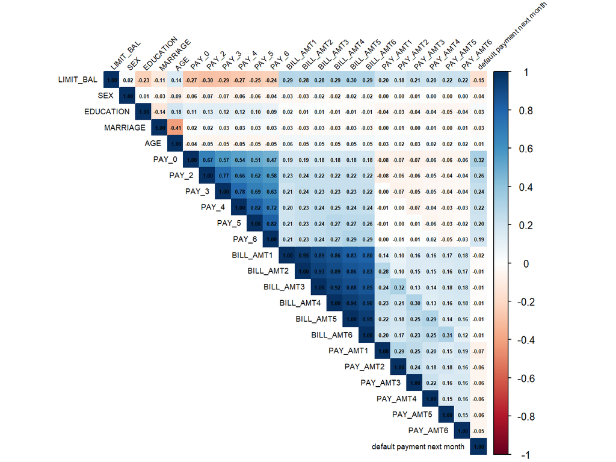

Matriz de correlación del dataset de crédito

```r
corrplot(matriz_cor,
         method = "color",
         type = "upper",
         tl.col = "black",
         tl.srt = 45,
         tl.cex = 0.6,
         addCoef.col = "black",
         number.cex = 0.4)
```